# Lab Two: Exploring Image Data

#### Sian Xiao & Tingting Zhao

## 1. Business Understanding

### 1.1 Data Source

The Chinese MNIST (Chinese numbers handwritten characters images) dataset is downloaded from [Kaggle](https://www.kaggle.com/gpreda/chinese-mnist). It's collected and modified from a [project at Newcastle University](https://data.ncl.ac.uk/articles/dataset/Handwritten_Chinese_Numbers/10280831/1).

In the original project, one hundred Chinese nationals took part in data collection. Each participant wrote with a standard black ink pen all 15 numbers in a table with 15 designated regions drawn on a white A4 paper. This process was repeated 10 times with each participant. Each sheet was scanned at the resolution of 300x300 pixels. It resulted a dataset of 15000 images, each representing one character from a set of 15 characters (grouped in samples, grouped in suites, with 10 samples/volunteer and 100 volunteers).

The modified dataset (Kaggle) contains the following:

- an index file, chinese_mnist.csv
- a folder with 15,000 jpg images, sized 64 x 64.

### 1.2 Data Significance

This is a optical character recognition (OCR) problem, and our task is to recognize the character each image has.

### 1.3 Data Description

The .csv file contains a data frame with following attributes:

- `suite_id`: There are totally 100 suites, each created by a volunteer.
- `sample_id`: Each volunteer created 10 samples.
- `code`: Each sample contains characters from 0 to 100M (totally 15 Chinese number characters). This is a code used to identify.
- `value`: Numerical value of each character.
- `character`:The actual Chinese character corresponding to one number.

The mapping of value, character and code is shown below:

| value | character | code |
| --- | --- | --- |
| 0 | 零 | 1 |
| 1 | 一 | 2 |
| 2 | 二 | 3 |
| 3 | 三 | 4 |
| 4 | 四 | 5 |
| 5 | 五 | 6 |
| 6 | 六 | 7 |
| 7 | 七 | 8 |
| 8 | 八 | 9 |
| 9 | 九 | 10 |
| 10 | 十 | 11 |
| 100 | 百 | 12 |
| 1000 | 千 | 13 |
| 10000 | 万 | 14 |
| 100000000 | 亿 | 15 |

```python
import os
import warnings
import random

import cv2
import matplotlib.pyplot as plt
import numpy as np
import pandas as pd
import seaborn as sns


warnings.simplefilter('ignore', DeprecationWarning)
%matplotlib inline
```

```python
data = pd.read_csv('data/chinese_mnist.csv', encoding='utf-8')
data.head()
```

|  | suite_id | sample_id | code | value | character |
| --- | --- | --- | --- | --- | --- |
| 0 | 1 | 1 | 10 | 9 | 九 |
| 1 | 1 | 10 | 10 | 9 | 九 |
| 2 | 1 | 2 | 10 | 9 | 九 |
| 3 | 1 | 3 | 10 | 9 | 九 |
| 4 | 1 | 4 | 10 | 9 | 九 |

```python
data_group = data.groupby(by='value')
data_group.character.value_counts()
```

```
value      character
0          零            1000
1          一            1000
2          二            1000
3          三            1000
4          四            1000
5          五            1000
6          六            1000
7          七            1000
8          八            1000
9          九            1000
10         十            1000
100        百            1000
1000       千            1000
10000      万            1000
100000000  亿            1000
Name: character, dtype: int64
```

```python
image_files = list(os.listdir("data/image"))
print(f"Number of image files in folder: {len(image_files)}")
print(f"Number of instances in csv: {len(data)}")
```

```
Number of image files in folder: 15000
Number of instances in csv: 15000
```

**So we can see we have 15 different classes, each has 1000 instances, which is consistent with the description of dataset. Also, there are 15000 image files, indicating no missing values/images.**

## 2. Data Preparation

```python
# cite from https://www.kaggle.com/derrelldsouza/chinese-mnist-digit-recognizer-using-hog-features
# function to create file name for each image in the input directory
def create_image_file_name(x):
    # input_{suite_id}_{sample_id}_{code}.jpg
    file_name = f"input_{x[0]}_{x[1]}_{x[2]}.jpg"
    return file_name


# append column for file names to original data
data["image_file"] = data.apply(create_image_file_name, axis=1)
data.head()
```

|  | suite_id | sample_id | code | value | character | image_file |
| --- | --- | --- | --- | --- | --- | --- |
| 0 | 1 | 1 | 10 | 9 | 九 | input_1_1_10.jpg |
| 1 | 1 | 10 | 10 | 9 | 九 | input_1_10_10.jpg |
| 2 | 1 | 2 | 10 | 9 | 九 | input_1_2_10.jpg |
| 3 | 1 | 3 | 10 | 9 | 九 | input_1_3_10.jpg |
| 4 | 1 | 4 | 10 | 9 | 九 | input_1_4_10.jpg |

### 2.1 Recolor images

```
Image hight: 64, Image width: 64
```

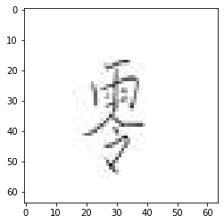

```python
# cite from https://stackoverflow.com/questions/51205502/convert-a-black-and-white-image-to-array-of-numbers
def read_image(name):
    path = 'data/image/' + name
    img = cv2.imread(path, 0)
    img_re = cv2.bitwise_not(img)
    img_new = img_re/255.0
    return img_new


path_example = 'input_1_1_1.jpg'
img_example = read_image(path_example)
h, w = img_example.shape
print(f"Image hight: {h}, Image width: {w}")
plt.imshow(img_example, cmap=plt.cm.gray)
plt.show()
```

### 2.2 Linearize images

```python
X = np.stack(data['image_file'].apply(read_image)).reshape(-1, h*w)
# target_labels
y = data['code'].to_numpy()
```

### 2.3 Visualize images

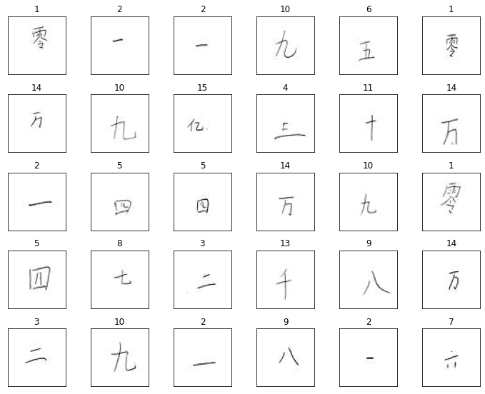

```python
# Here I modified the plot_gallery function to choose images randomly.
# The data frame is collected by code, so the first 100 rows are all the same characters.

def plot_gallery(images, labels, h, w, n_row=5, n_col=6, random_=False):
    """Helper function to plot a gallery of portraits"""
    plt.figure(figsize=(1.6 * n_col, 1.6 * n_row))
    plt.subplots_adjust(bottom=0, left=.01, right=.99, top=.90, hspace=.35)
    for i in range(n_row * n_col):
        plt.subplot(n_row, n_col, i + 1)
        index = random.randrange(0, len(images)) if random_ else i
        plt.imshow(images[index].reshape((h, w)), cmap=plt.cm.gray)
        plt.title(labels[index], size=12)
        plt.xticks(())
        plt.yticks(())


plot_gallery(X, y, h, w, random_=True)
```

## 3. Data Reduction

### 3.1 PCA

```python
from sklearn.decomposition import PCA
n_components = 2000
%time pca = PCA(n_components=n_components).fit(X)
```

```
CPU times: user 5min 37s, sys: 1min 48s, total: 7min 26s
Wall time: 15.5 s
```

```
0.9998137252881317
```

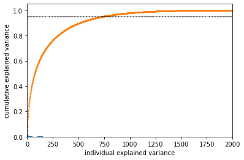

```python
explained_var = pca.explained_variance_ratio_
cum_var_exp = np.cumsum(explained_var)
print(cum_var_exp[-1])
plt.bar(range(explained_var.shape[0]), explained_var)
plt.scatter(range(cum_var_exp.shape[0]), cum_var_exp, s=1)
plt.scatter(range(0, cum_var_exp.shape[0], 10), [
            0.95]*int(cum_var_exp.shape[0]/10), s=0.2, color="black")
plt.xlim(-1, 2000)
plt.xlabel('individual explained variance')
plt.ylabel('cumulative explained variance')
```

**According to the plot of cumulative explained variation, the first 750 components explain more than 95% of the variance(the black line is cumulative explained variance equal to 0.95), so the first 750 components are adequate to represent the image data.**

```
CPU times: user 2min 7s, sys: 39.4 s, total: 2min 46s
Wall time: 6.04 s
0.9512917145696418
```

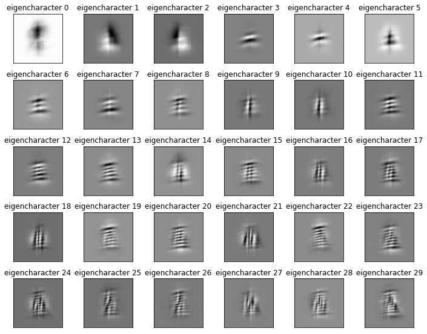

```python
n_components = 750
pca = PCA(n_components)
%time pca.fit(X.copy())
explained_var = pca.explained_variance_ratio_
cum_var_exp = np.cumsum(explained_var)
print(cum_var_exp[-1])
eigencharacters = pca.components_.reshape((n_components, h, w))
eigencharacter_titles = ["eigencharacter %d" %
                         i for i in range(eigencharacters.shape[0])]
plot_gallery(eigencharacters, eigencharacter_titles, h, w, random_=False)
```

**Same with PCA, from here we can see the eigen characters: for example the first row eigen characters are similar to character "零", "八", "一", "十"**

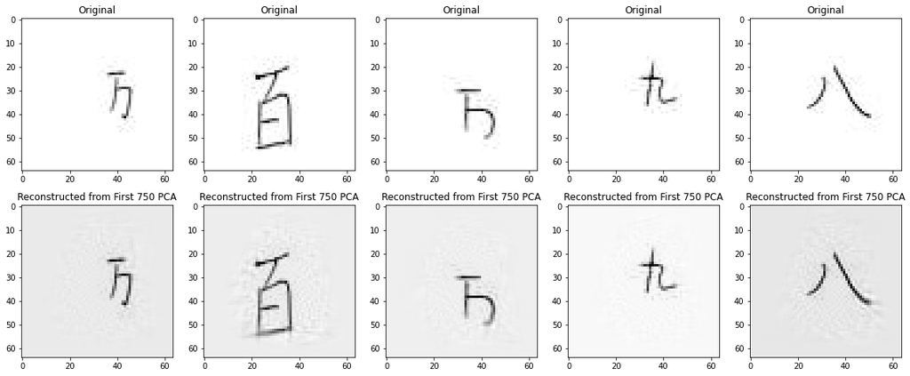

```python
def reconstruct_image(trans_obj, org_features):
    low_rep = trans_obj.transform(org_features)
    rec_image = trans_obj.inverse_transform(low_rep)
    return low_rep, rec_image


n_row = 2
n_col = 5
plt.figure(figsize=(4 * n_col, 4 * n_row))
for i in range(n_col):
    idx_to_reconstruct = random.randrange(0, len(X))
    X_idx = X[idx_to_reconstruct]
    low_dimensional_representation, reconstructed_image = reconstruct_image(
        pca, X_idx.reshape(1, -1))
    plt.subplot(n_row, n_col, i + 1)
    plt.imshow(X_idx.reshape((h, w)), cmap=plt.cm.gray)
    plt.title('Original')
    plt.grid(False)
    plt.subplot(n_row, n_col, i + 6)
    plt.imshow(reconstructed_image.reshape((h, w)), cmap=plt.cm.gray)
    plt.title('Reconstructed from First 750 PCA')
    plt.grid(False)
```

**The top row shows the input images, while the bottom row shows the reconstruction of the images from just 750 out of the initial 4096 features. The plot shows the first 750 eigen vectors contain enough information represent the images.**

### 3.2 Random PCA

```python
from sklearn.decomposition import PCA
n_components = 2000
%time rpca = PCA(n_components=n_components, svd_solver='randomized').fit(X)
```

```
CPU times: user 5min 33s, sys: 1min 20s, total: 6min 53s
Wall time: 14.3 s
```

```
0.9998136031919118
```

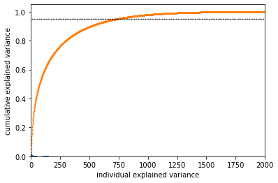

```python
explained_var = rpca.explained_variance_ratio_
cum_var_exp = np.cumsum(explained_var)
print(cum_var_exp[-1])
plt.bar(range(explained_var.shape[0]), explained_var)
plt.scatter(range(cum_var_exp.shape[0]), cum_var_exp, s=1)
plt.scatter(range(0, cum_var_exp.shape[0], 10), [
            0.95]*int(cum_var_exp.shape[0]/10), s=0.2, color="black")
plt.xlim(-1, 2000)
plt.xlabel('individual explained variance')
plt.ylabel('cumulative explained variance')
```

**Same results as PCA, the first 750 components explains more than 95% of the variance.**

```
CPU times: user 2min 3s, sys: 34.2 s, total: 2min 38s
Wall time: 5.85 s
0.9512917145696418
```

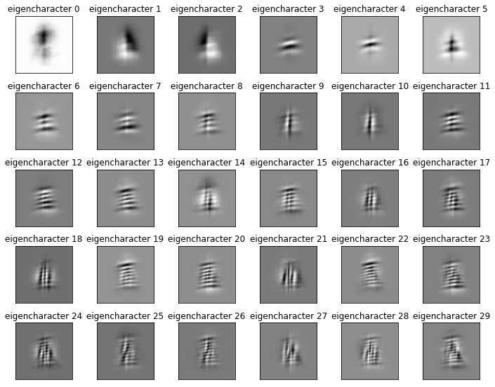

```python
n_components = 750
rpca = PCA(n_components=n_components, svd_solver='randomized')
%time rpca.fit(X.copy())
explained_var = pca.explained_variance_ratio_
cum_var_exp = np.cumsum(explained_var)
print(cum_var_exp[-1])
eigencharacters = rpca.components_.reshape((n_components, h, w))
eigencharacter_titles = ["eigencharacter %d" %
                         i for i in range(eigencharacters.shape[0])]
plot_gallery(eigencharacters, eigencharacter_titles, h, w, random_=False)
```

**Same with PCA, from here we can see the eigen characters: for example the first row eigen characters are similar to character "零", "八", "一", "十"**

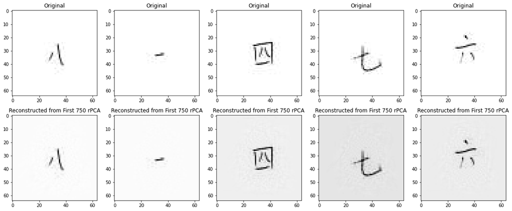

```python
def reconstruct_image(trans_obj, org_features):
    low_rep = trans_obj.transform(org_features)
    rec_image = trans_obj.inverse_transform(low_rep)
    return low_rep, rec_image


n_row = 2
n_col = 5
plt.figure(figsize=(4 * n_col, 4 * n_row))
for i in range(n_col):
    idx_to_reconstruct = random.randrange(0, len(X))
    X_idx = X[idx_to_reconstruct]
    low_dimensional_representation, reconstructed_image = reconstruct_image(
        rpca, X_idx.reshape(1, -1))
    plt.subplot(n_row, n_col, i + 1)
    plt.imshow(X_idx.reshape((h, w)), cmap=plt.cm.gray)
    plt.title('Original')
    plt.grid(False)
    plt.subplot(n_row, n_col, i + 6)
    plt.imshow(reconstructed_image.reshape((h, w)), cmap=plt.cm.gray)
    plt.title('Reconstructed from First 750 rPCA')
    plt.grid(False)
```

**Same results as from PCA, the plot shows the first 750 eigen vectors contain enough information represent the images.**

### 3.3 PCA vs random PCA

```python
from ipywidgets import fixed
import copy
from sklearn.metrics.pairwise import pairwise_distances
```

```python
n_components = 750
X_pca_features = PCA(n_components=n_components).fit_transform(copy.deepcopy(X))
X_rpca_features = PCA(n_components=n_components,
                      svd_solver='randomized').fit_transform(copy.deepcopy(X))
```

```python
from sklearn.neighbors import KNeighborsClassifier
from sklearn.metrics import accuracy_score
from sklearn.model_selection import train_test_split


def acc(X_pca_features, X_rpca_features, y):
    knn_pca = KNeighborsClassifier(n_neighbors=1)
    knn_rpca = KNeighborsClassifier(n_neighbors=1)
    pca_train, pca_test, rpca_train, rpca_test, y_train, y_test = train_test_split(
        X_pca_features, X_rpca_features, y, test_size=0.2, train_size=0.8)
    knn_pca.fit(pca_train, y_train)
    acc_pca = accuracy_score(knn_pca.predict(pca_test), y_test)
    knn_rpca.fit(rpca_train, y_train)
    acc_rpca = accuracy_score(knn_rpca.predict(rpca_test), y_test)
    return 100*acc_pca, 100*acc_rpca


pca, rpca = [], []
for i in range(10):
    acc_pca, acc_rpca = acc(X_pca_features, X_rpca_features, y)
    pca.append(acc_pca)
    rpca.append(acc_rpca)

pca_mean, pca_std = round(np.mean(pca), 2), round(np.std(pca), 2)
rpca_mean, rpca_std = round(np.mean(rpca), 2), round(np.std(rpca), 2)

print(f"PCA feature accuracy:{pca_mean}, PCA feature std: {pca_std}")
print(
    f"random PCA feature accuracy: {rpca_mean}, random PCA feature std: {rpca_std}")
```

```
PCA feature accuracy:54.37, PCA feature std: 0.77
random PCA feature accuracy: 54.47, random PCA feature std: 0.81
```

| N component |  | PCA |  |  | rPCA |  |
| --- | --- | --- | --- | --- | --- | --- |
|  | wall time | Cum_var | Accuracy | wall time | Cum_var | Accuracy |
| 2000 | 15.5 s | 0.9998 | \ | 14.3 s | 0.9998 | \ |
| 750 | 6.04 s | 0.9513 | 54.37(0.77) | 5.85 s | 0.9513 | 54.47(0.81) |

**According to the cumulative explained variation and KNeighborsClassifier model accuracy, PCA and random PCA are of same ability at representing the images with fewer components. However, random PCA is faster when the component is larger(2000). So random PCA is preferred because it maintains the same accuracy at the same time is faster to compute.**

### 3.4 DAISY

```
(2, 2, 136)
544
```

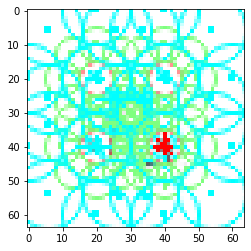

```python
from skimage.feature import daisy
idx_to_reconstruct = int(np.random.rand(1)*len(X))
img = X[idx_to_reconstruct].reshape((h, w))
# lets first visualize what the daisy descriptor looks like
features, img_desc = daisy(img,
                           step=20,
                           radius=20,
                           rings=2,
                           histograms=8,
                           orientations=8,
                           visualize=True)
plt.imshow(img_desc)
plt.grid(False)
print(features.shape)
print(features.shape[0]*features.shape[1]*features.shape[2])
```

```python
def apply_daisy(row, shape):
    feat = daisy(row.reshape(shape), step=20, radius=20,
                 rings=2, histograms=8, orientations=8,
                 visualize=False)
    return feat.reshape((-1))


%time daisy_features = np.apply_along_axis(apply_daisy, 1, X, (h, w))
print(daisy_features.shape)
```

```
CPU times: user 2min 48s, sys: 184 ms, total: 2min 48s
Wall time: 2min 48s
(15000, 544)
```

```python
from sklearn.metrics.pairwise import pairwise_distances
# find the pairwise distance between all the different image features
%time dist_matrix = pairwise_distances(daisy_features)
```

```
CPU times: user 9.72 s, sys: 6.49 s, total: 16.2 s
Wall time: 2.48 s
```

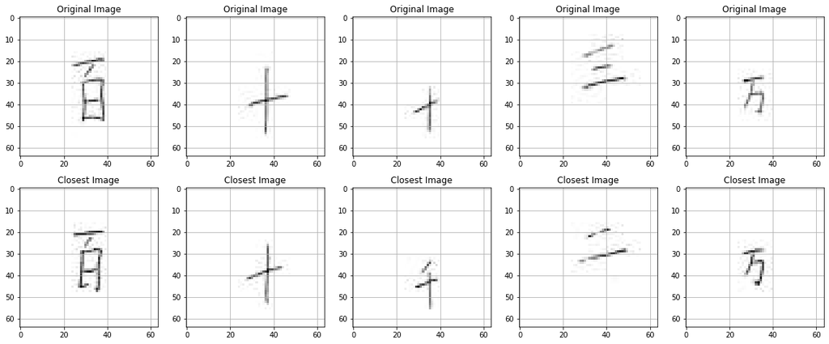

```python
import copy
# find closest image to current image
n_row = 2
n_col = 5
plt.figure(figsize=(4 * n_col, 4 * n_row))
for i in range(n_col):
    idx1 = int(np.random.rand(1)*len(X))
    distances = copy.deepcopy(dist_matrix[idx1, :])
    distances[idx1] = np.infty  # dont pick the same image!
    idx2 = np.argmin(distances)
    plt.subplot(n_row, n_col, i+1)
    plt.imshow(X[idx1].reshape((h, w)), cmap=plt.cm.gray)
    plt.title("Original Image")
    plt.grid()
    plt.subplot(n_row, n_col, i+6)
    plt.imshow(X[idx2].reshape((h, w)), cmap=plt.cm.gray)
    plt.title("Closest Image")
    plt.grid()
```

### 3.5 DAISY feature extraction analysis

```python
dist_matrix = pairwise_distances(daisy_features)
```

```python
dist_matrix_mean = np.ones((15, 15))
for i in range(15):
    for j in range(15):
        dist_matrix_mean[i, j] = np.mean(
            dist_matrix[1000*i:1000*(i+1), 1000*j:1000*(j+1)])
```

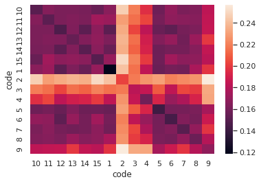

```python
cmap = sns.set(style="darkgrid")  # one of the many styles to plot using
sns.heatmap(dist_matrix_mean, cmap=cmap, vmin=np.min(
    dist_matrix_mean), vmax=np.max(dist_matrix_mean))
plt.yticks(np.arange(0, 15, 1))
plt.yticks([i+0.5 for i in range(15)], y[::1000])
plt.xticks(np.arange(0, 15, 1))
plt.xticks([i+0.5 for i in range(15)], y[::1000])
plt.xlabel("code")
plt.ylabel("code")
plt.show()
```

**The distance matrix map shows DAISY feature can easily capture the difference between Chinese digits "一" (code 2), "二" (code 3), "三" (code 4), "八" (code 9) and others.**

```python
def acc(X_pca_features, daisy_features, y):
    knn_pca = KNeighborsClassifier(n_neighbors=1)
    knn_dsy = KNeighborsClassifier(n_neighbors=1)

    pca_train, pca_test, dsy_train, dsy_test, y_train, y_test = train_test_split(
        X_pca_features, daisy_features, y, test_size=0.2, train_size=0.8)

    knn_pca.fit(pca_train, y_train)
    acc_pca = accuracy_score(knn_pca.predict(pca_test), y_test)

    knn_dsy.fit(dsy_train, y_train)
    acc_dsy = accuracy_score(knn_dsy.predict(dsy_test), y_test)

    return 100*acc_pca, 100*acc_dsy


pca, dsy = [], []
for i in range(10):
    acc_pca, acc_dsy = acc(X_pca_features, daisy_features, y)
    pca.append(acc_pca)
    dsy.append(acc_dsy)

pca_mean, pca_std = round(np.mean(pca), 2), round(np.std(pca), 2)
dsy_mean, dsy_std = round(np.mean(dsy), 2), round(np.std(dsy), 2)

print(f"PCA feature accuracy: {pca_mean}, PCA feature accuracy std: {pca_std}")
print(
    f"DAISY feature accuracy: {dsy_mean}, DAISY feature accuracy std: {dsy_std}")
```

```
PCA feature accuracy: 54.24, PCA feature accuracy std: 0.95
DAISY feature accuracy: 87.15, DAISY feature accuracy std: 0.47
```

**According to the nearest neighbor classifier accuracy, the accuracy is 33% higher than PCA extracted feature, which indicating Daisy extraction method is better at representing the image data.**

## 4.Exceptional Work

### 4.1 Explore the influence of DAISY feature extraction to accuracy

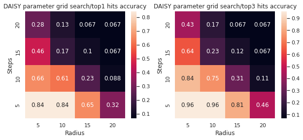

```python
lines = open("test.txt", "r").readlines()
top1_accu = [float(l.split()[4].split("%")[0]) for l in lines if "top1" in l]
top2_accu = [float(l.split()[4].split("%")[0]) for l in lines if "top2" in l]
top3_accu = [float(l.split()[4].split("%")[0])
             for l in lines if "top3" in l and "succedd" in l]
top1_accuracies = np.zeros((4, 4))
top3_accuracies = np.zeros((4, 4))
for i in range(16):
    top1_accuracies[i//4, i % 4] = top1_accu[i]
    top3_accuracies[i//4, i % 4] = (np.array(top1_accu) +
                                    np.array(top2_accu)+np.array(top3_accu))[i]
fig, ax = plt.subplots(figsize=(10, 4))
cmap = sns.set(style="darkgrid")
plt.subplot(1, 2, 1)
sns.heatmap(top1_accuracies/100, cmap=cmap, annot=True)
plt.gca().invert_yaxis()
plt.ylabel("Steps")
plt.xlabel("Radius")
plt.title("DAISY parameter grid search/top1 hits accuracy")
plt.xticks([i+0.5 for i in range(4)], range(5, 21, 5))
plt.yticks([i+0.5 for i in range(4)], range(5, 21, 5))

plt.subplot(1, 2, 2)
sns.heatmap(top3_accuracies/100, cmap=cmap, annot=True)
plt.ylabel("Steps")
plt.xlabel("Radius")
plt.title("DAISY parameter grid search/top3 hits accuracy")
plt.xticks([i+0.5 for i in range(4)], range(5, 21, 5))
plt.yticks([i+0.5 for i in range(4)], range(5, 21, 5))
plt.gca().invert_yaxis()
```

**Considering calculation time, we did the DAISY parameter search on [M2](https://www.smu.edu/OIT/Services/HPC), here we only show the grid search results and demonstrate using the best parameter in following block. The files `test.py` and `test.txt` can be found [here](https://github.com/SianXiaoCHN/SMU-CS7324-2021Fall/blob/main/homework/Lab_2).**

**The heatmap on the left shows the accuracy of top1 hits, the one on the right shows the accuracy of top3 hits. As the plot shows: For Chinese MNIST data set, when steps or radius parameters are larger the accuracies are lower. However, when step or radius are small(=5 for example), the change of radius to accuracy is less sensitive than the change of step to accuracy.**

**Which is quite intuitive: When step is large, there is space in the image left uncaptured, so the accuracy is low; when radius is big, because the size differences of written Chinese character, key point in one image capture the whole character, key point in another image may only capture part of the character, which will also end up with low accuracy. In this case, tune the ring number parameter may get better accuracy.**

**One point need to be mentioned, there is a lot of empty space in the figure (all white, or all black in the original images), pre-process the image more may also enhance the accuracy: for example, get rid off all the white spaces and center the characters.**

### 4.2 Key point matching method

```python
from multiprocessing import Pool
from skimage.feature import match_descriptors, daisy


def train_test_split(X, y):
    # split training and testing set randomly. won't have bais because every person write 10 times
    X_train, X_test, y_train, y_test = [], [], [], []
    for code in range(15):
        index = list(range(1000))
        random.seed(7324)
        random.shuffle(index)
        for i in index[:500]:
            X_train.append(X[code*1000+i])
            y_train.append(y[code*1000+i])
        for i in index[500:]:
            X_test.append(X[code*1000+i])
            y_test.append(y[code*1000+i])
    return X_train, X_test, y_train, y_test


def extract_descriptors(imgSet, step, radius, rings):
    # extract DAISY feature
    desSet = []
    for img_1d in imgSet:
        img_2d = img_1d.reshape(64, 64)
        fea = daisy(img_2d, step=step, radius=radius, rings=rings,
                    histograms=8, orientations=8, visualize=False)
        des = fea.reshape(fea.shape[0]*fea.shape[1], -1)
        desSet.append(des)
    return desSet


def massive_matching_DAISY(des_img):
    # kep point match
    match_numbers = []
    for i, des in enumerate(X_train):
        matches = match_descriptors(
            des_img, des, cross_check=True,  metric=None, p=2, max_distance=np.inf, max_ratio=1.0)
        match_numbers.append((matches.shape[0], i))

    match_numbers.sort(key=lambda x: -x[0])  # sort as most matching points
    return y_train[match_numbers[0][1]], y_train[match_numbers[1][1]], y_train[match_numbers[2][1]]


# split training and testing set
X_train, X_test, y_train, y_test = train_test_split(X, y)
X_train = extract_descriptors(X_train, 5, 10, 2)
X_test = extract_descriptors(X_test, 5, 10, 2)


# parallel running key point match
with Pool(36) as p:
    results = p.map(massive_matching_DAISY, [i for i in X_test])


# hit count
top1, top2, top3 = [0]*15, [0]*15, [0]*15
for i, des in enumerate(X_test):
    one, two, three = results[i]
    if one == y_test[i]:
        top1[y_test[i]-1] += 1
    elif two == y_test[i]:
        top2[y_test[i]-1] += 1
    elif three == y_test[i]:
        top3[y_test[i]-1] += 1

fail = [500-top1[i]-top2[i]-top3[i] for i in range(15)]
```

```python
# hit percent
match_scores = pd.DataFrame(data=np.array(top1)/500, columns=["top1"])
match_scores["top2"] = np.array(top2)/500
match_scores["top3"] = np.array(top3)/500
match_scores["fail"] = np.array(fail)/500
```

**For each code, we randomly took 500 as training and 500 as testing, so end up with 7500 training and 7500 testing.**

```
succeed as top1 for 84.27%
succeed as top2 for 92.35%
succeed as top3 for 95.64%
can't be found as top3 for 4.36%
```

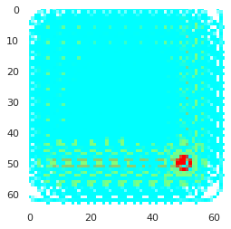

```python
# visualize what the daisy descriptor looks like
idx_to_reconstruct = int(np.random.rand(1)*len(X))
img = X[idx_to_reconstruct].reshape((h, w))

features, img_desc = daisy(img,
                           step=5,
                           radius=10,
                           rings=2,
                           histograms=8,
                           orientations=8,
                           visualize=True)
plt.imshow(img_desc)
plt.grid(False)

print(f"succeed as top1 for {round(sum(top1)/len(X_test)*100,2)}%")
print(f"succeed as top2 for {round((sum(top1)+sum(top2))/len(X_test)*100,2)}%")
print(
    f"succeed as top3 for {round((sum(top1)+sum(top2)+sum(top3))/len(X_test)*100,2)}%")
print(f"can't be found as top3 for {round(sum(fail)/len(X_test)*100,2)}%")
```

**With DAISY parameter, step=5, radius=10, the whole image is well covered and described. As we can see, the top1 hit accuracy is 84.27%, the top3 hit (hit top1 or top2 or top3) accuracy reaches to 96%.**

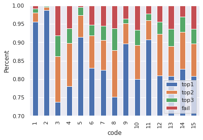

```python
match_scores.plot.bar(stacked=True)
plt.xticks(range(15), range(1, 16))
plt.ylim(0.7, 1.)
plt.xlabel("code")
plt.ylabel("Percent")
```

**From the results we can see, code 1 (character "零"), code 2 (character "一"), code 5 (character "四"), code 9 (character "八"), code 11(character "十") can be accurately predicted (more than 90%), probably because they are very distinguishable from other characters(character "零", "四"), or because they are kind of eigen characters (character "一", "八", "十"). Though the correlation matrices from 3.5 shows the DAISY feature can easily capture the difference between the eighen characters(character "一", "八") from others, we are using key point matching which doesn't focus on the whole feature space, so the method may struggle at distinguishing the characters containing these eigen characters from the eigen characters.**